# Capstone Project Creation

### IBM SkillsBuild Europe Delivery - Data Analytics

# Pre-requisite

- Understanding of Python, Power BI or Tableau
- Understanding of Data Cleaning
- Understanding Data Visualization

#### Level of Exercise: Intermediate

#### Duration: approximately 3 hours

### Data Analytics of Airbnb Data:

#### Objective:

In this exericise, you will be performing Data Analytics on an Open Dataset dataset coming from Airbnb. Some of the tasks include

- Data Cleaning.
- Data Transformation
- Data Visualization.

#### Overview of Airbnb Data:

People's main criteria when visiting new places are reasonable accommodation and food. Airbnb (Air-Bed-Breakfast) is an online marketplace created to meet this need of people by renting out their homes for a short term. They offer this facility at a relatively lower price than hotels. Further people worldwide prefer the homely and economical service offered by them. They offer services across various geographical locations

#### Dataset Source

YOu can get the dataset for this assessment using the following link: https://www.kaggle.com/datasets/arianazmoudeh/airbnbopendata

This dataset contains information such as the neighborhood offering these services, room type, price,avaliabilty, reviews, service fee, cancellation policy and rules to use the house. This analysis will help airbnb in improving its services.

So all the best for your Data Analytics Journey on Airbnb data!!!

## Task 1: Data Loading (Python)

1. Read the csv file and load it into a pandas dataframe.
2. Display the first five rows of your dataframe.
3. Display the data types of the columns.

```python
## Read the csv file
import pandas as pd
import numpy as np
from matplotlib import pyplot as plt
import seaborn as sns
data= pd.read_csv("C:/Users/Ruchika jain/OneDrive\Desktop/IBM DATA ANALYST/Programming In Python For Data Analytics And Data Science/Airbnb_Open_Data.csv",low_memory=False)
```

```python
## Display the first 5 rows
data.head()
```

|  | id | NAME | host id | host_identity_verified | host name | neighbourhood group | neighbourhood | lat | long | country | ... | service fee | minimum nights | number of reviews | last review | reviews per month | review rate number | calculated host listings count | availability 365 | house_rules | license |
| --- | --- | --- | --- | --- | --- | --- | --- | --- | --- | --- | --- | --- | --- | --- | --- | --- | --- | --- | --- | --- | --- |
| 0 | 1001254 | Clean & quiet apt home by the park | 80014485718 | unconfirmed | Madaline | Brooklyn | Kensington | 40.64749 | -73.97237 | United States | ... | $193 | 10.0 | 9.0 | 10/19/2021 | 0.21 | 4.0 | 6.0 | 286.0 | Clean up and treat the home the way you'd like... | NaN |
| 1 | 1002102 | Skylit Midtown Castle | 52335172823 | verified | Jenna | Manhattan | Midtown | 40.75362 | -73.98377 | United States | ... | $28 | 30.0 | 45.0 | 5/21/2022 | 0.38 | 4.0 | 2.0 | 228.0 | Pet friendly but please confirm with me if the... | NaN |
| 2 | 1002403 | THE VILLAGE OF HARLEM....NEW YORK ! | 78829239556 | NaN | Elise | Manhattan | Harlem | 40.80902 | -73.94190 | United States | ... | $124 | 3.0 | 0.0 | NaN | NaN | 5.0 | 1.0 | 352.0 | I encourage you to use my kitchen, cooking and... | NaN |
| 3 | 1002755 | NaN | 85098326012 | unconfirmed | Garry | Brooklyn | Clinton Hill | 40.68514 | -73.95976 | United States | ... | $74 | 30.0 | 270.0 | 7/5/2019 | 4.64 | 4.0 | 1.0 | 322.0 | NaN | NaN |
| 4 | 1003689 | Entire Apt: Spacious Studio/Loft by central park | 92037596077 | verified | Lyndon | Manhattan | East Harlem | 40.79851 | -73.94399 | United States | ... | $41 | 10.0 | 9.0 | 11/19/2018 | 0.10 | 3.0 | 1.0 | 289.0 | Please no smoking in the house, porch or on th... | NaN |

5 rows × 26 columns

```python
## Display the data types
data.info()
```

```
<class 'pandas.core.frame.DataFrame'>
RangeIndex: 102599 entries, 0 to 102598
Data columns (total 26 columns):
 #   Column                          Non-Null Count   Dtype
---  ------                          --------------   -----
 0   id                              102599 non-null  int64
 1   NAME                            102349 non-null  object
 2   host id                         102599 non-null  int64
 3   host_identity_verified          102310 non-null  object
 4   host name                       102193 non-null  object
 5   neighbourhood group             102570 non-null  object
 6   neighbourhood                   102583 non-null  object
 7   lat                             102591 non-null  float64
 8   long                            102591 non-null  float64
 9   country                         102067 non-null  object
```

[output cut: 18 more lines]

## Task 2a: Data Cleaning (Any Tool)

1. Drop some of the unwanted columns. These include `host id`, `id`, `country` and `country code` from the dataset.
2. State the reason for not including these columns for your Data Analytics.

If using Python for this exercise, please include the code in the cells below. If using any other tool, please include screenshoots before and after the elimination of the columns.

```python
#Drop some of the unwanted columns. These include host id, id, country and country code from the dataset.
data.drop(['host id','country','id','country code'],axis=1, inplace= True)
data.head()
```

|  | NAME | host_identity_verified | host name | neighbourhood group | neighbourhood | lat | long | instant_bookable | cancellation_policy | room type | ... | service fee | minimum nights | number of reviews | last review | reviews per month | review rate number | calculated host listings count | availability 365 | house_rules | license |
| --- | --- | --- | --- | --- | --- | --- | --- | --- | --- | --- | --- | --- | --- | --- | --- | --- | --- | --- | --- | --- | --- |
| 0 | Clean & quiet apt home by the park | unconfirmed | Madaline | Brooklyn | Kensington | 40.64749 | -73.97237 | False | strict | Private room | ... | $193 | 10.0 | 9.0 | 10/19/2021 | 0.21 | 4.0 | 6.0 | 286.0 | Clean up and treat the home the way you'd like... | NaN |
| 1 | Skylit Midtown Castle | verified | Jenna | Manhattan | Midtown | 40.75362 | -73.98377 | False | moderate | Entire home/apt | ... | $28 | 30.0 | 45.0 | 5/21/2022 | 0.38 | 4.0 | 2.0 | 228.0 | Pet friendly but please confirm with me if the... | NaN |
| 2 | THE VILLAGE OF HARLEM....NEW YORK ! | NaN | Elise | Manhattan | Harlem | 40.80902 | -73.94190 | True | flexible | Private room | ... | $124 | 3.0 | 0.0 | NaN | NaN | 5.0 | 1.0 | 352.0 | I encourage you to use my kitchen, cooking and... | NaN |
| 3 | NaN | unconfirmed | Garry | Brooklyn | Clinton Hill | 40.68514 | -73.95976 | True | moderate | Entire home/apt | ... | $74 | 30.0 | 270.0 | 7/5/2019 | 4.64 | 4.0 | 1.0 | 322.0 | NaN | NaN |
| 4 | Entire Apt: Spacious Studio/Loft by central park | verified | Lyndon | Manhattan | East Harlem | 40.79851 | -73.94399 | False | moderate | Entire home/apt | ... | $41 | 10.0 | 9.0 | 11/19/2018 | 0.10 | 3.0 | 1.0 | 289.0 | Please no smoking in the house, porch or on th... | NaN |

5 rows × 22 columns

```python
##State the reason for not including these columns for your Data Analytics.
These columns are included because these columns doesnot add value to the data set. Such columns don’t help in predicting the output, so we remove them from the dataset.
```

```python
pd.set_option('display.max_columns',None)
data.head()
```

[output not shown]

## Task 2b: Data Cleaning (Python)

- Check for missing values in the dataframe and display the count in ascending order. **If the values are missing, impute the values as per the datatype of the columns.**
- Check whether there are any duplicate values in the dataframe and, if present, remove them.
- Display the total number of records in the dataframe before and after removing the duplicates.

```python
data.dtypes
```

```
NAME                               object
host_identity_verified             object
host name                          object
neighbourhood group                object
neighbourhood                      object
lat                               float64
long                              float64
instant_bookable                   object
cancellation_policy                object
room type                          object
Construction year                 float64
price                              object
service fee                        object
minimum nights                    float64
number of reviews                 float64
last review                        object
reviews per month                 float64
review rate number                float64
calculated host listings count    float64
availability 365                  float64
house_rules                        object
license                            object
dtype: object
```

```python
## Check for missing values in the dataframe and display the count in ascending order.
data.isnull().sum().sort_values()
```

```
room type                              0
lat                                    8
long                                   8
neighbourhood                         16
neighbourhood group                   29
cancellation_policy                   76
instant_bookable                     105
number of reviews                    183
Construction year                    214
price                                247
NAME                                 250
service fee                          273
host_identity_verified               289
calculated host listings count       319
review rate number                   326
host name                            406
minimum nights                       409
availability 365                     448
reviews per month                  15879
last review                        15893
house_rules                        52131
license                           102597
dtype: int64
```

```python
#Check whether there are any duplicate values in the dataframe and, if present, remove them.
#Display the total number of records in the dataframe before and after removing the duplicates.
data.shape
```

```
(102599, 22)
```

```python
data.duplicated().sum()
```

```
3436
```

```python
data.drop_duplicates(inplace=True)
data.shape
```

```
(99163, 22)
```

## Task 3: Data Transformation (Any Tool)

- Rename the column `availability 365` to `days_booked`
- Convert all column names to lowercase and replace the spaces in the column names with an underscore "_".
- Remove the dollar sign and comma from the columns `price` and `service_fee`. If necessary, convert these two columns to the appropriate data type.

If using Python for this exercise, please include the code in the cells below. If using any other tool, please include screenshoots of your work.

```python
## Rename the column availability 365 to days_booked
data.rename(columns= {'availability 365':'days_booked'},inplace=True)
data.columns
```

```
Index(['NAME', 'host_identity_verified', 'host name', 'neighbourhood group',
       'neighbourhood', 'lat', 'long', 'instant_bookable',
       'cancellation_policy', 'room type', 'Construction year', 'price',
       'service fee', 'minimum nights', 'number of reviews', 'last review',
       'reviews per month', 'review rate number',
       'calculated host listings count', 'days_booked', 'house_rules',
       'license'],
      dtype='object')
```

```python
## Convert all column names to lowercase and replace the spaces with an underscore "_"
data.columns
```

```
Index(['NAME', 'host_identity_verified', 'host name', 'neighbourhood group',
       'neighbourhood', 'lat', 'long', 'instant_bookable',
       'cancellation_policy', 'room type', 'Construction year', 'price',
       'service fee', 'minimum nights', 'number of reviews', 'last review',
       'reviews per month', 'review rate number',
       'calculated host listings count', 'days_booked', 'house_rules',
       'license'],
      dtype='object')
```

```python
data.columns = [x.lower().replace(" ", "_") for x in data.columns]
```

```python
data.columns
```

```
Index(['name', 'host_identity_verified', 'host_name', 'neighbourhood_group',
       'neighbourhood', 'lat', 'long', 'instant_bookable',
       'cancellation_policy', 'room_type', 'construction_year', 'price',
       'service_fee', 'minimum_nights', 'number_of_reviews', 'last_review',
       'reviews_per_month', 'review_rate_number',
       'calculated_host_listings_count', 'days_booked', 'house_rules',
       'license'],
      dtype='object')
```

```python
## Remove the dollar sign and comma from the columns. If necessary, convert these two columns to the appropriate data type.
data[['price','service_fee']].head()
```

|  | price | service_fee |
| --- | --- | --- |
| 0 | $966 | $193 |
| 1 | $142 | $28 |
| 2 | $620 | $124 |
| 3 | $368 | $74 |
| 4 | $204 | $41 |

```python
data['price']= data['price'].str.replace("$","").str.replace(",","")
data['service_fee']= data['service_fee'].str.replace("$","").str.replace(",","")

data['price'] = data['price'].astype(float)
data = data.dropna(subset=['price'])
```

```python
data.dtypes
```

```
name                               object
host_identity_verified             object
host_name                          object
neighbourhood_group                object
neighbourhood                      object
lat                               float64
long                              float64
instant_bookable                   object
cancellation_policy                object
room_type                          object
construction_year                 float64
price                             float64
service_fee                        object
minimum_nights                    float64
number_of_reviews                 float64
last_review                        object
reviews_per_month                 float64
review_rate_number                float64
calculated_host_listings_count    float64
days_booked                       float64
house_rules                        object
license                            object
dtype: object
```

```python
data['service_fee '] = data['service_fee'].fillna(0,inplace= True)

data['price'] = data['price'].astype(int)
```

```python
data[['price','service_fee']].head(100)
```

|  | price | service_fee |
| --- | --- | --- |
| 0 | 966 | 193 |
| 1 | 142 | 28 |
| 2 | 620 | 124 |
| 3 | 368 | 74 |
| 4 | 204 | 41 |
| ... | ... | ... |
| 95 | 360 | 72 |
| 96 | 380 | 76 |
| 97 | 343 | 69 |
| 98 | 160 | 32 |
| 99 | 528 | 106 |

100 rows × 2 columns

```python
data['price']=data['price'].astype(int)
```

### Task 4: Exploratory Data Analysis (Any Tool)

- List the count of various room types avaliable in the dataset.
- Which room type has the most strict cancellation policy?
- List the average price per neighborhood group, and highlight the most expensive neighborhood to rent from.

If using Python for this exercise, please include the code in the cells below. If using any other tool, please include screenshoots of your work.

```python
## List the count of various room types avaliable with Airbnb
data['room_type'].unique()
```

```
array(['Private room', 'Entire home/apt', 'Shared room', 'Hotel room'],
      dtype=object)
```

```python
data['room_type'].value_counts()
```

```
Entire home/apt    51870
Private room       44789
Shared room         2142
Hotel room           115
Name: room_type, dtype: int64
```

```python
## Which room type adheres to more strict cancellation policy
data['cancellation_policy'].unique()
```

```
array(['strict', 'moderate', 'flexible', nan], dtype=object)
```

```python
data_prep= data[data['cancellation_policy']== 'strict']
data_prep.shape
```

```
(32848, 23)
```

```python
data_prep['room_type'].value_counts()
```

```
Entire home/apt    17195
Private room       14904
Shared room          715
Hotel room            34
Name: room_type, dtype: int64
```

```python
#List the average price per neighborhood group, and highlight the most expensive neighborhood to rent from.
grp_avg = data['price'].groupby(data['neighbourhood_group']).mean().sort_values(ascending=False).reset_index()
grp_avg
```

|  | neighbourhood_group | price |
| --- | --- | --- |
| 0 | Queens | 629.712735 |
| 1 | Bronx | 626.614412 |
| 2 | Staten Island | 626.431843 |
| 3 | Brooklyn | 626.428192 |
| 4 | Manhattan | 622.683781 |
| 5 | brookln | 580.000000 |
| 6 | manhatan | 460.000000 |

## Task 5a: Data Visualization (Any Tool)

- List the count of various room types avaliable with Airnb
- Which room type adheres to more strict cancellation policy
- List the prices by neighborhood group and also mention which is the most expensive neighborhood group for rentals
- List the top 10 neighborhoods in the increasing order of their price with the help of a horizontal bar graph. Which is the cheapest neighborhood.
- List the neighborhoods which offer short term rentals within 10 days. Illustrate with a bar graph
- List the prices with respect to room type using a bar graph and also state your inferences.
- Create a pie chart that shows distribution of booked days for each neighborhood group .Which neighborhood has the highest booking percentage.

If using Python for this exercise, please include the code in the cells below. If using any other tool, please include screenshoots of your work.

```python
## List the prices by neighborhood group and also mention which is the most expensive neighborhood group for rent from
data_grp = data['price'].groupby(data['neighbourhood_group']).max().sort_values(ascending= False).reset_index()
data_grp
```

|  | neighbourhood_group | price |
| --- | --- | --- |
| 0 | Staten Island | 1200 |
| 1 | Queens | 1200 |
| 2 | Manhattan | 1200 |
| 3 | Brooklyn | 1200 |
| 4 | Bronx | 1200 |
| 5 | brookln | 580 |
| 6 | manhatan | 460 |

```python
#List the top 10 neighborhoods in the increasing order of their price with the help of a horizontal bar graph.
#Which is the cheapest neighborhood.

grp2 = data['price'].groupby(data['neighbourhood']).sum().sort_values(ascending=False)
grp2.head(10)
```

```
neighbourhood
Bedford-Stuyvesant    4782134
Williamsburg          4659604
Harlem                3316270
Bushwick              3035466
Hell's Kitchen        2394057
Upper West Side       2305160
Upper East Side       2175764
East Village          2077759
Midtown               1984887
Crown Heights         1941184
Name: price, dtype: int32
```

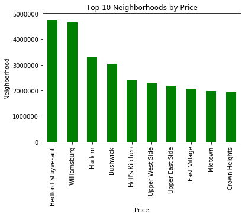

```python
grp2.head(10).plot(kind='bar',color={'green'})
plt.title('Top 10 Neighborhoods by Price')
plt.xlabel('Price')
plt.ylabel('Neighborhood')
plt.show()
```

```python
#List the neighborhoods which offer short term rentals within 10 days. Illustrate with a bar graph
data.head()
```

|  | name | host_identity_verified | host_name | neighbourhood_group | neighbourhood | lat | long | instant_bookable | cancellation_policy | room_type | construction_year | price | service_fee | minimum_nights | number_of_reviews | last_review | reviews_per_month | review_rate_number | calculated_host_listings_count | days_booked | house_rules | license | service_fee |
| --- | --- | --- | --- | --- | --- | --- | --- | --- | --- | --- | --- | --- | --- | --- | --- | --- | --- | --- | --- | --- | --- | --- | --- |
| 0 | Clean & quiet apt home by the park | unconfirmed | Madaline | Brooklyn | Kensington | 40.64749 | -73.97237 | False | strict | Private room | 2020.0 | 966 | 193 | 10.0 | 9.0 | 10/19/2021 | 0.21 | 4.0 | 6.0 | 286.0 | Clean up and treat the home the way you'd like... | NaN | None |
| 1 | Skylit Midtown Castle | verified | Jenna | Manhattan | Midtown | 40.75362 | -73.98377 | False | moderate | Entire home/apt | 2007.0 | 142 | 28 | 30.0 | 45.0 | 5/21/2022 | 0.38 | 4.0 | 2.0 | 228.0 | Pet friendly but please confirm with me if the... | NaN | None |
| 2 | THE VILLAGE OF HARLEM....NEW YORK ! | NaN | Elise | Manhattan | Harlem | 40.80902 | -73.94190 | True | flexible | Private room | 2005.0 | 620 | 124 | 3.0 | 0.0 | NaN | NaN | 5.0 | 1.0 | 352.0 | I encourage you to use my kitchen, cooking and... | NaN | None |
| 3 | NaN | unconfirmed | Garry | Brooklyn | Clinton Hill | 40.68514 | -73.95976 | True | moderate | Entire home/apt | 2005.0 | 368 | 74 | 30.0 | 270.0 | 7/5/2019 | 4.64 | 4.0 | 1.0 | 322.0 | NaN | NaN | None |
| 4 | Entire Apt: Spacious Studio/Loft by central park | verified | Lyndon | Manhattan | East Harlem | 40.79851 | -73.94399 | False | moderate | Entire home/apt | 2009.0 | 204 | 41 | 10.0 | 9.0 | 11/19/2018 | 0.10 | 3.0 | 1.0 | 289.0 | Please no smoking in the house, porch or on th... | NaN | None |

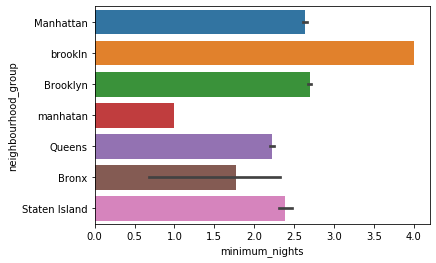

```python
import seaborn as sns
data_minimum_nights = data[data['minimum_nights']<10]
data_minimum_nights['neighbourhood_group']

sns.barplot(data= data_minimum_nights,x= 'minimum_nights',y='neighbourhood_group')
```

```python
#List the prices with respect to room type using a bar graph and also state your inferences.

grouped = data.groupby('room_type')['price'].mean().sort_values(ascending=False)
grouped.head()
```

```
room_type
Hotel room         666.391304
Shared room        632.439309
Entire home/apt    625.263948
Private room       624.818326
Name: price, dtype: float64
```

[figure not shown]

```python
grouped.head(10).plot(kind='bar',color={'green'})
plt.title('Top 10 Neighborhoods by Price')
plt.xlabel('Price')
plt.ylabel('room_type')
plt.show()
```

```python
#Create a pie chart that shows distribution of booked days for each neighborhood group .Which neighborhood has the highest booking percentage.
data.columns
```

```
Index(['name', 'host_identity_verified', 'host_name', 'neighbourhood_group',
       'neighbourhood', 'lat', 'long', 'instant_bookable',
       'cancellation_policy', 'room_type', 'construction_year', 'price',
       'service_fee', 'minimum_nights', 'number_of_reviews', 'last_review',
       'reviews_per_month', 'review_rate_number',
       'calculated_host_listings_count', 'days_booked', 'house_rules',
       'license', 'service_fee '],
      dtype='object')
```

```python
data[['neighbourhood_group','days_booked']].head(10)
data1= data['days_booked'].groupby(data['neighbourhood_group']).mean().sort_values(ascending=False).reset_index()
data1
```

|  | neighbourhood_group | days_booked |
| --- | --- | --- |
| 0 | manhatan | 325.000000 |
| 1 | Staten Island | 195.953057 |
| 2 | Bronx | 179.266487 |
| 3 | Queens | 162.845393 |
| 4 | Manhattan | 142.836433 |
| 5 | Brooklyn | 130.881793 |
| 6 | brookln | 47.000000 |

[output not shown]

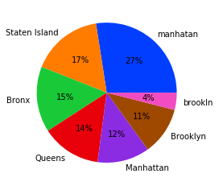

```python
palette_color = sns.color_palette('bright')

plt.pie(data1['days_booked'], labels=data1['neighbourhood_group'],colors=palette_color, autopct='%.0f%%')
```

## Task 5b: Data Visualization (Any Tool)

- Does service price and room price have an impact on each other. Illustrate this relationship with a scatter plot and state your inferences
- Using a line graph show in which year the maximum construction of rooms took place.

If using Python for this exercise, please include the code in the cells below. If using any other tool, please include screenshoots of your work.

```python
data.dtypes
```

```
name                               object
host_identity_verified             object
host_name                          object
neighbourhood_group                object
neighbourhood                      object
lat                               float64
long                              float64
instant_bookable                   object
cancellation_policy                object
room_type                          object
construction_year                 float64
price                               int32
service_fee                        object
minimum_nights                    float64
number_of_reviews                 float64
last_review                        object
reviews_per_month                 float64
review_rate_number                float64
calculated_host_listings_count    float64
days_booked                       float64
house_rules                        object
license                            object
service_fee                        object
dtype: object
```

```python
data['service_fee']=data['service_fee'].astype(int)
```

```python
#Does service price and room price have an impact on each other. Illustrate this relationship with a scatter plot and state your inference
```

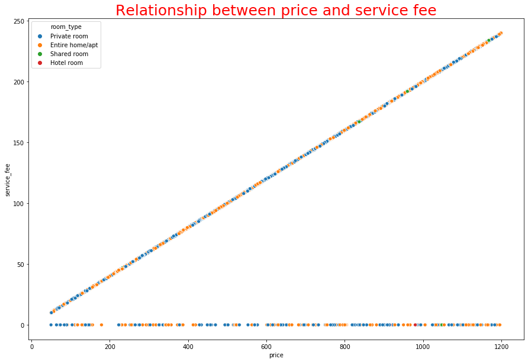

```python
plt.figure(figsize=(15,10))
plt.title('Relationship between price and service fee', size=25, color='red')
#sns.scatterplot(x=data['price'],y=data['service_fee'], hue=data['room_type'])
sns.scatterplot(data=data,x='price',y='service_fee',hue='room_type')
```

```python
data.head()
```

|  | name | host_identity_verified | host_name | neighbourhood_group | neighbourhood | lat | long | instant_bookable | cancellation_policy | room_type | construction_year | price | service_fee | minimum_nights | number_of_reviews | last_review | reviews_per_month | review_rate_number | calculated_host_listings_count | days_booked | house_rules | license | service_fee |
| --- | --- | --- | --- | --- | --- | --- | --- | --- | --- | --- | --- | --- | --- | --- | --- | --- | --- | --- | --- | --- | --- | --- | --- |
| 0 | Clean & quiet apt home by the park | unconfirmed | Madaline | Brooklyn | Kensington | 40.64749 | -73.97237 | False | strict | Private room | 2020.0 | 966 | 193 | 10.0 | 9.0 | 10/19/2021 | 0.21 | 4.0 | 6.0 | 286.0 | Clean up and treat the home the way you'd like... | NaN | None |
| 1 | Skylit Midtown Castle | verified | Jenna | Manhattan | Midtown | 40.75362 | -73.98377 | False | moderate | Entire home/apt | 2007.0 | 142 | 28 | 30.0 | 45.0 | 5/21/2022 | 0.38 | 4.0 | 2.0 | 228.0 | Pet friendly but please confirm with me if the... | NaN | None |
| 2 | THE VILLAGE OF HARLEM....NEW YORK ! | NaN | Elise | Manhattan | Harlem | 40.80902 | -73.94190 | True | flexible | Private room | 2005.0 | 620 | 124 | 3.0 | 0.0 | NaN | NaN | 5.0 | 1.0 | 352.0 | I encourage you to use my kitchen, cooking and... | NaN | None |
| 3 | NaN | unconfirmed | Garry | Brooklyn | Clinton Hill | 40.68514 | -73.95976 | True | moderate | Entire home/apt | 2005.0 | 368 | 74 | 30.0 | 270.0 | 7/5/2019 | 4.64 | 4.0 | 1.0 | 322.0 | NaN | NaN | None |
| 4 | Entire Apt: Spacious Studio/Loft by central park | verified | Lyndon | Manhattan | East Harlem | 40.79851 | -73.94399 | False | moderate | Entire home/apt | 2009.0 | 204 | 41 | 10.0 | 9.0 | 11/19/2018 | 0.10 | 3.0 | 1.0 | 289.0 | Please no smoking in the house, porch or on th... | NaN | None |

```python
#Using a line graph show in which year the maximum construction of rooms took place.
data['construction_year_counts']=data['construction_year'].value_counts()
#sns.lineplot(x='construction_year',y='construction_year_counts',data=data)
#plt.show()
data['construction_year'].dropna(inplace=True)
```

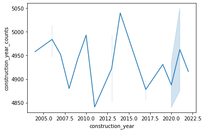

```python
sns.lineplot(x='construction_year',y='construction_year_counts',data=data)
plt.show()
```

```python
data['construction_year'].value_counts().sort_values(ascending=False)
```

```
2014.0    5050
2008.0    5040
2006.0    5014
2020.0    4993
2009.0    4993
2019.0    4991
2010.0    4958
2003.0    4952
2022.0    4947
2005.0    4942
2012.0    4935
2007.0    4931
2015.0    4916
2017.0    4900
2011.0    4880
2018.0    4875
2021.0    4856
2004.0    4852
2016.0    4841
2013.0    4840
Name: construction_year, dtype: int64
```

## Task 5c: Data Visualization (Any Tool)

- With the help of box plots illustrate the following
  - Effect of Review Rate number on price
  - Effect of host identity verified on price

If using Python for this exercise, please include the code in the cells below. If using any other tool, please include screenshoots of your work.

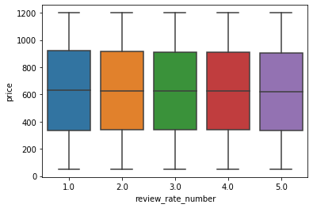

```python
#Effect of Review Rate number on price
sns.boxplot(x='review_rate_number',y='price',data=data)
```

```python
#Effect of host identity verified on price
```

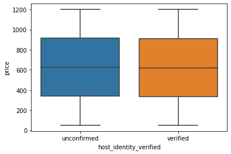

```python
sns.boxplot(x='host_identity_verified',y='price',data=data)
```